# 03b_analyze_DTM

Erin Becker

October 17, 2017

## Analyze the Document Term Matrix

This continues our analysis of document similarity based on shared entries.

Note: The “EXTRA” tag indicates a hidden code chunk illustrating an important point about the data that is tangential to the main thread of the analysis. You can run these code chunks by setting eval=TRUE and see the code itself by setting echo=TRUE.

Load in the document term matrix (DTM) that was generated previously.

### Check how R parsed the DTM

R doesn’t allow variable names to start with a number, so entries starting with a number had “X” added to the beggining of the entry name. R doesn’t allow parentheses or brackets in variable names, so entries like “1(ban₂)[na]na” parsed as “X1.ban…na.na”

```
##         X1.2.na.na_giŋ.unit.n X5.6.na.na_sila.unit.n a.arm.n_apin.plow.n
## P117395                     0                      0                   0
## P117404                     0                      0                   0
## P128345                     0                      0                   0
## P224980                     0                      0                   0
## P224986                     0                      0                   0
## P224994                     0                      0                   0
```

In a later cell, we will sum the columns and rows to get an idea of the density of the matrix. In order to avoid iteratively summing the summary column and summary row, we need to set variables specifying the columns and rows we want to sum.

```
## [1]  138 3376
```

### Check density of DTM

Two attributes of the DTM which are of interest to us are:

1. Distribution of document lengths (number of entries per document).
2. Distribution of entry frequency (number of times each entry appears across the corpus). Note that an entry may appear multiple times in a single document.

We will look at these two distributions below.

Note that entries may appear multiple times in a single document (EXTRA).

We next add a column showing the number of entries in each document, a row showing the number of occurences of each entry, and set the intersection of these two sumamries to NA.

We can see the distribution of document length by looking at a histogram.

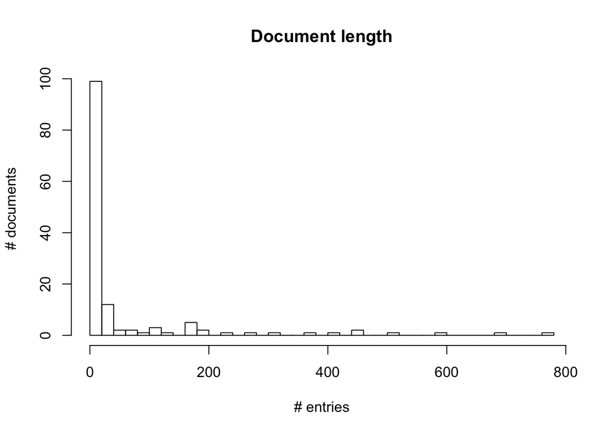

There are 56 documents with 10 or more entries and 22 documents with 100 or more entries.

We see that the majority of documents are very short. However, there are a decent number of documents with a substantial number of entries (summarized above).

## Look at document length

Which documents are the longest?

```
##         num_entries
## Q000039         778
## P273880         698
## P271911         592
## Q000001         511
## P271301         452
## P247864         445
```

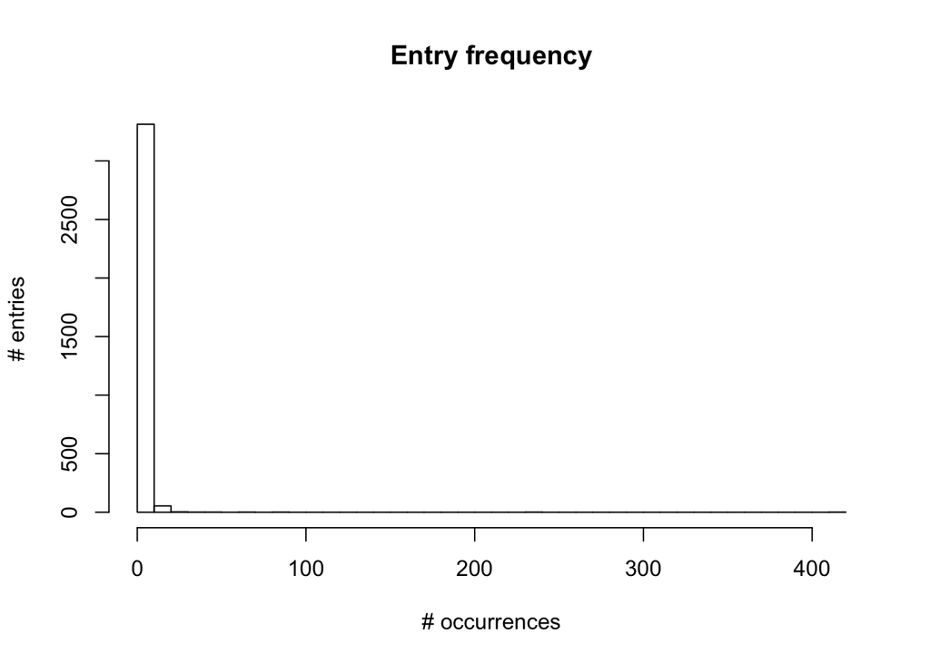

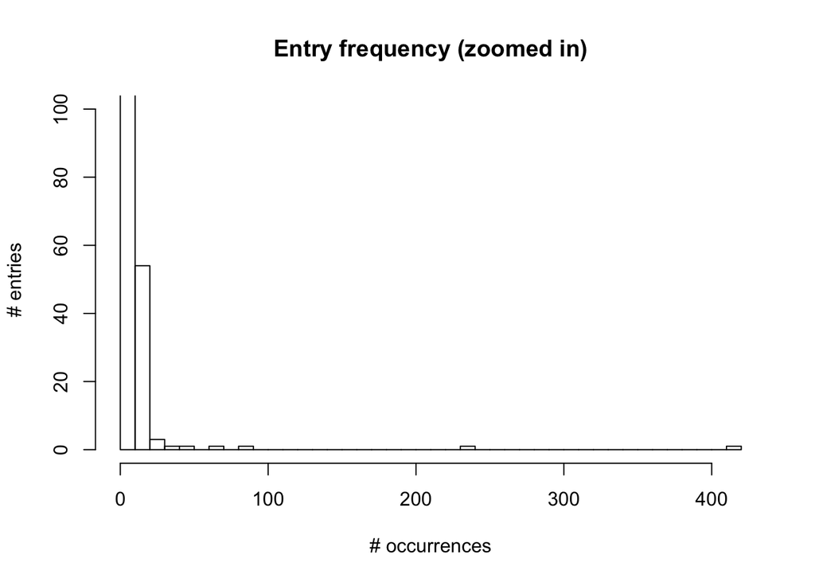

We then look at the distribution of entries across the corpus.

78.41% of entries appear only once or twice across the corpus. 83 entries occur 10 or more times within the corpus, including one that occurs 416 times within the 138 documents. The most common entry is unknown.

Below we inspect the most common entries (those that appear at least ten times across the corpus) to see if they make sense.

## Look at some of the most common entries

```
##  [1] "al.hoe.n"
##  [2] "al.hoe.n_zu.tooth.n_eš.three.nu"
##  [3] "al.hoe.n_zu.tooth.n_limmu.four.nu"
##  [4] "al.hoe.n_zu.tooth.n_min.two.nu"
##  [5] "allanum.oak.n"
##  [6] "apin.plow.n_tugsaga.plow.n"
##  [7] "apin.plow.n_šu.hand.n"
##  [8] "apin.plow.n_šudu.equipped.aj"
##  [9] "buniŋ.trough.n_x.na.na"
## [10] "dih.weed.n"
## [11] "dilim.spoon.n"
## [12] "e.house.n_gigir.chariot.n"
## [13] "ellag.ball.n"
## [14] "esi.tree.n"
## [15] "gigir.chariot.n"
```

[output cut: 68 more lines]

As seen from the output above, many of the most common entries include either unlematizable or illegible words (represented as x.na.na or x.x.na.na). These are not particularly informative. We want to remove these entries from the analysis. Also remove the entry “unknown”.

Look again at entry frequency after removing these entries.

Note that we must re-create the summary column and row after excluding these entries.

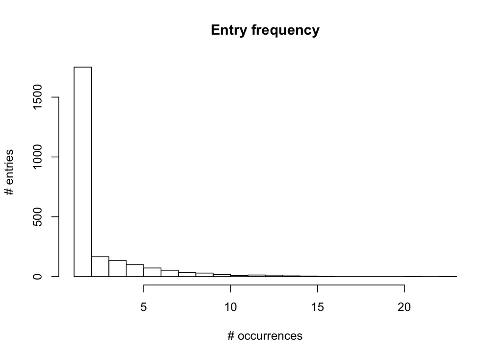

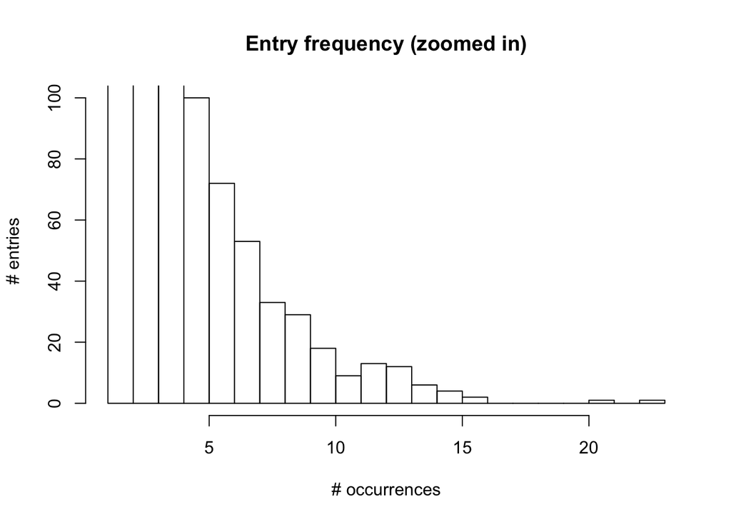

72.81% of entries appear only once or twice across the corpus. 66 entries occur 10 or more times within the corpus, including one that occurs 23 times within the 138 documents. The most common entry is kid.da.twig.n. Now some of the most common entries are:

```
##  [1] "al.hoe.n"
##  [2] "al.hoe.n_zu.tooth.n_eš.three.nu"
##  [3] "al.hoe.n_zu.tooth.n_limmu.four.nu"
##  [4] "al.hoe.n_zu.tooth.n_min.two.nu"
##  [5] "allanum.oak.n"
##  [6] "apin.plow.n_tugsaga.plow.n"
##  [7] "apin.plow.n_šu.hand.n"
##  [8] "apin.plow.n_šudu.equipped.aj"
##  [9] "dih.weed.n"
## [10] "dilim.spoon.n"
## [11] "e.house.n_gigir.chariot.n"
## [12] "ellag.ball.n"
## [13] "esi.tree.n"
## [14] "gigir.chariot.n"
## [15] "girim.flower.n"
```

[output cut: 51 more lines]

Next we will reorganize our data to enable pretty and informative plotting of entry distribution across documents and overall frequency.

First, we reorder the columns in our dataframe from alphabetical to sorting by frequency so that the most common entries are clustered together for ease of visualization.

To do this, we first convert the frequency counts to presence/absence (binary), then reorder the columns by column sums.

We then recalculate number of occurrences and number of entries. These are now binary, so they represent:

- num_occurrences = number of documents in which an entry appears
- num_entries = number of unique entries in a document (excluding “na.na” and “unknown” entries)

1507 entries appear in only one document. The entry that appears in the most documents is peš.fig.n, šagkal.tree.n.

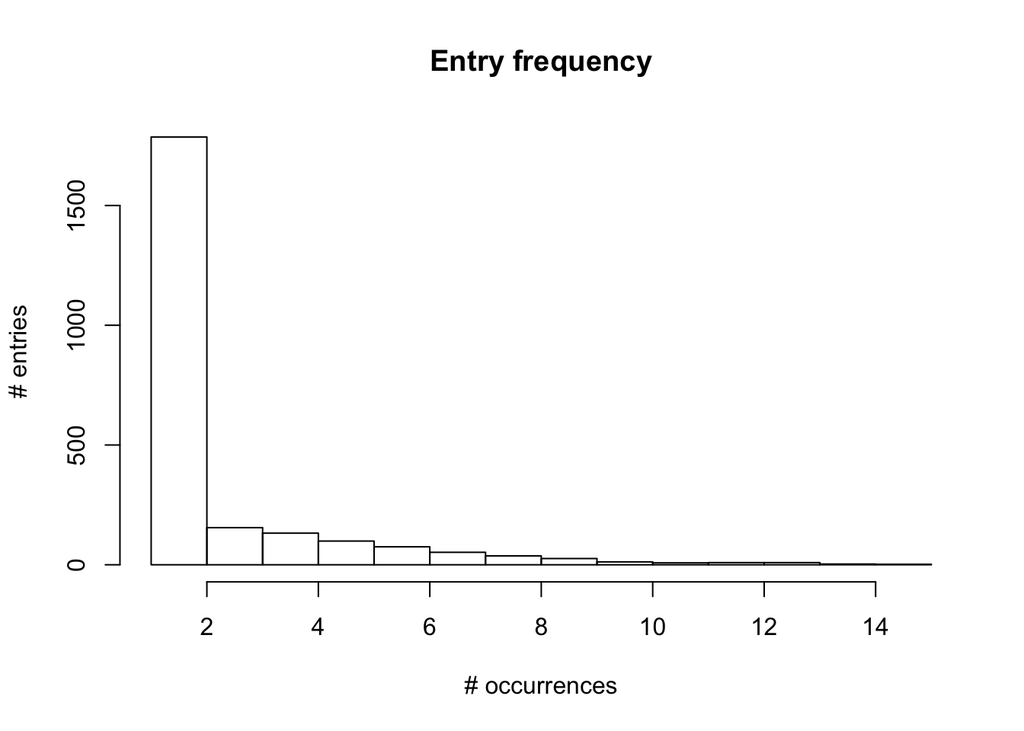

These entries appear in at least 10 different documents:

```
##  [1] "peš.fig.n"
##  [2] "šagkal.tree.n"
##  [3] "allanum.oak.n"
##  [4] "ŋeštin.vine.n"
##  [5] "ŋeštinkira.berry.n"
##  [6] "al.hoe.n"
##  [7] "esi.tree.n"
##  [8] "gigir.chariot.n"
##  [9] "hašhur.apple.n"
## [10] "hašhur.apple.n_kur.mountain.n"
## [11] "ildag.poplar.n"
## [12] "lamgal.nut.n"
## [13] "ŋeštinguruma..vine.n"
## [14] "šennur.plum.n"
## [15] "e.house.n_gigir.chariot.n"
```

[output cut: 28 more lines]

Our dataset is built around lists of trees and wooden objects (composite text Q000039). For sanity testing our analyses, we’ve included some outlier texts which are not part of the lists of trees and wooden objects document group. One of the outlier text is Q000001, which is a composite text of lists of animals. Before using this text as an outlier, we want to make sure that it doesn’t share many similarities with Q000039. We find very few shared entries between Q000039 and Q000001. (EXTRA)

### Remove rare entries

A large number of entries appear only in one document in the corpus. We remove these from the remainder of the analysis. However, we want to keep all entries from our outlier texts. After removing rare entries, the dimensions of our dtm are:

```
## [1]  139 2405
```

Our next step is to compare this presence/absence distribution of entries across documents to understand which documents are most similar to one another at the entry level. First we will extract only those texts with at least ten entries to see if patterns make sense before analyzing the shorter texts. After removing short texts, the dimmensions of our dataframe are:

```
## [1]   43 2405
```

### Write out cleaned dtm

After these cleaning steps, we now have the DTM that we will use for our remaining analyses. We will write out a copy of this dataframe so that we can pass it in as an object to other scripts.

```r
#add document names as row names
dtm_df$document = rownames(dtm_df)

write.csv(dtm_df, "data/dtm_data/dtm_df_clean.csv", quote = FALSE)
```